# Practical Machine Learning

Rajeeth

April 7, 2018

### Synopsis

The objective and goal of this project is to predict the manner in which they performed the exercise and machine learning classification of accelerometers data on the belt, forearm, arm, and dumbell of 6 participants.In training data “classe” is the outcome variable in the training set using predictor variables to predict 20 different test cases.The data for this project come from this source is: http://groupware.les.inf.puc-rio.br/har.

The “classe” variable which classifies the correct and incorrect outcomes of A, B, C, D, and E categories. Coursera project writeup describes the model cross validation and expected out of sample error rate. Models applied successfully to predict all 20 different test cases on the Coursera website.

This project work partially submitted to the Coursera for the course “Practical Machine Learning” by Jeff Leek, PhD, Professor at Johns Hopkins University, Bloomberg School of Public Health.

Load Require library set the seed

```r
library(e1071)
library(rattle)
library(rpart)
library(randomForest)
library(caret)
set.seed(9999)
```

Load The data from downloaded CSV files

```r
data_train <-  read.csv("C:/Users/Rajeethkumar/Desktop/Data/Coursera/Pml/pml-training.csv")
data_test <- read.csv("C:/Users/Rajeethkumar/Desktop/Data/Coursera/Pml/pml-testing.csv")
```

## Feature Engineering

We have seen the training data and testing data contains lot of NA values and timestamp values,at this stage remove columns which contains NA and columns that contains users information and columns gives timetamp values. We concentrate on test data feature because train and test data columns can cause integrity problem.

```r
features <- names(data_test[,colSums(is.na(data_test)) == 0])[8:59]
data_train <- data_train[,c(features,'classe')]
data_test <- data_test[,c(features,"problem_id")]
print(dim(data_train))
```

```
## [1] 19622    53
```

```r
print(dim(data_test))
```

```
## [1] 20 53
```

## Train and Validation set preparation

We use 60% data to fit the model and use other set to evaluate the model.

```r
inTrain <- createDataPartition(data_train$classe, p=0.6, list=FALSE)
training <- data_train[inTrain,]
testing <- data_train[-inTrain,]

dim(training)
```

```
## [1] 11776    53
```

```r
dim(testing)
```

```
## [1] 7846   53
```

### Build Decision Tree classifier and look at the accuray and ploting

```r
mod_DT <- rpart(classe ~ ., data = training, method="class",  control = rpart.control(method = "cv", number = 10))
prediction1 <- predict(mod_DT, testing, type="class" )

confusionMatrix(prediction1, testing$classe)
```

```
## Confusion Matrix and Statistics
##
##           Reference
## Prediction    A    B    C    D    E
##          A 2014  324   36  119   54
##          B   47  832   71   31   84
##          C   65  152 1096  217  186
##          D   72   96   76  821   88
##          E   34  114   89   98 1030
##
## Overall Statistics
##
##                Accuracy : 0.7383
##                  95% CI : (0.7285, 0.748)
##     No Information Rate : 0.2845
##     P-Value [Acc > NIR] : < 2.2e-16
##
##                   Kappa : 0.6676
##  Mcnemar's Test P-Value : < 2.2e-16
##
## Statistics by Class:
##
##                      Class: A Class: B Class: C Class: D Class: E
## Sensitivity            0.9023   0.5481   0.8012   0.6384   0.7143
## Specificity            0.9051   0.9632   0.9043   0.9494   0.9477
## Pos Pred Value         0.7907   0.7812   0.6387   0.7121   0.7546
## Neg Pred Value         0.9589   0.8988   0.9556   0.9305   0.9364
## Prevalence             0.2845   0.1935   0.1744   0.1639   0.1838
## Detection Rate         0.2567   0.1060   0.1397   0.1046   0.1313
## Detection Prevalence   0.3246   0.1357   0.2187   0.1470   0.1740
## Balanced Accuracy      0.9037   0.7556   0.8527   0.7939   0.8310
```

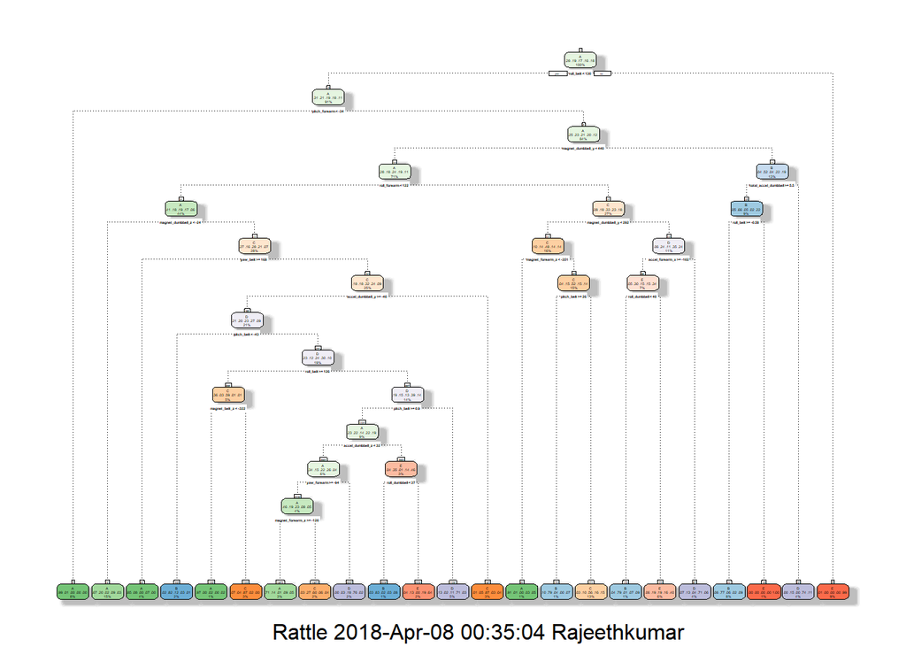

```r
fancyRpartPlot(mod_DT)
```

This Decision tree gives 0.7383,which is pretty much enough.

### Build Random Forest Alogritm and look at the accuray and ploting

```r
mod_RF <- randomForest(classe ~ ., data = training, method = "rf", importance = T,
                                    trControl = trainControl(method = "cv", classProbs=TRUE,
                                    savePredictions=TRUE,allowParallel=TRUE, number = 10))

prediction2 <- predict(mod_RF,testing,type = "class")
confusionMatrix(prediction2 , testing$classe)
```

```
## Confusion Matrix and Statistics
##
##           Reference
## Prediction    A    B    C    D    E
##          A 2231    3    0    0    0
##          B    1 1513   10    0    0
##          C    0    2 1357   21    6
##          D    0    0    1 1262    5
##          E    0    0    0    3 1431
##
## Overall Statistics
##
##                Accuracy : 0.9934
##                  95% CI : (0.9913, 0.995)
##     No Information Rate : 0.2845
##     P-Value [Acc > NIR] : < 2.2e-16
##
##                   Kappa : 0.9916
##  Mcnemar's Test P-Value : NA
##
## Statistics by Class:
##
##                      Class: A Class: B Class: C Class: D Class: E
## Sensitivity            0.9996   0.9967   0.9920   0.9813   0.9924
## Specificity            0.9995   0.9983   0.9955   0.9991   0.9995
## Pos Pred Value         0.9987   0.9928   0.9791   0.9953   0.9979
## Neg Pred Value         0.9998   0.9992   0.9983   0.9964   0.9983
## Prevalence             0.2845   0.1935   0.1744   0.1639   0.1838
## Detection Rate         0.2843   0.1928   0.1730   0.1608   0.1824
## Detection Prevalence   0.2847   0.1942   0.1767   0.1616   0.1828
## Balanced Accuracy      0.9995   0.9975   0.9937   0.9902   0.9960
```

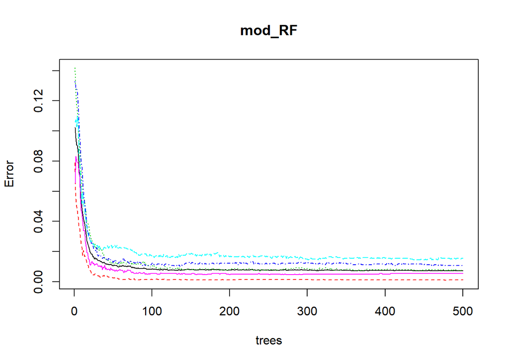

```r
plot(mod_RF)
```

This Random Forest gives 0.9934,which is pretty much enough.

### Build Gradient boosting classifier and have a look at the accuray and ploting

```r
mod_GBM <- train(classe ~ ., method = "gbm", data = training,
                    verbose = F,
                    trControl = trainControl(method = "cv", number = 10))


preditction3 <- predict(mod_GBM,testing)
confusionMatrix(preditction3 , testing$classe)
```

```
## Confusion Matrix and Statistics
##
##           Reference
## Prediction    A    B    C    D    E
##          A 2195   41    0    0    2
##          B   20 1439   27    3   24
##          C    8   32 1325   51   16
##          D    6    5   16 1228   27
##          E    3    1    0    4 1373
##
## Overall Statistics
##
##                Accuracy : 0.9635
##                  95% CI : (0.9592, 0.9676)
##     No Information Rate : 0.2845
##     P-Value [Acc > NIR] : < 2.2e-16
##
##                   Kappa : 0.9539
##  Mcnemar's Test P-Value : 5.788e-16
##
## Statistics by Class:
##
##                      Class: A Class: B Class: C Class: D Class: E
## Sensitivity            0.9834   0.9480   0.9686   0.9549   0.9521
## Specificity            0.9923   0.9883   0.9835   0.9918   0.9988
## Pos Pred Value         0.9808   0.9511   0.9253   0.9579   0.9942
## Neg Pred Value         0.9934   0.9875   0.9933   0.9912   0.9893
## Prevalence             0.2845   0.1935   0.1744   0.1639   0.1838
## Detection Rate         0.2798   0.1834   0.1689   0.1565   0.1750
## Detection Prevalence   0.2852   0.1928   0.1825   0.1634   0.1760
## Balanced Accuracy      0.9879   0.9681   0.9760   0.9733   0.9755
```

```r
print(mod_GBM)
```

```
## Stochastic Gradient Boosting
##
## 11776 samples
##    52 predictor
##     5 classes: 'A', 'B', 'C', 'D', 'E'
##
## No pre-processing
## Resampling: Cross-Validated (10 fold)
## Summary of sample sizes: 10597, 10597, 10599, 10598, 10599, 10598, ...
## Resampling results across tuning parameters:
##
##   interaction.depth  n.trees  Accuracy   Kappa
##   1                   50      0.7538201  0.6878634
##   1                  100      0.8211587  0.7737009
##   1                  150      0.8531737  0.8142128
##   2                   50      0.8554650  0.8168725
##   2                  100      0.9048897  0.8796174
##   2                  150      0.9274775  0.9082227
##   3                   50      0.8938496  0.8656032
##   3                  100      0.9396205  0.9235988
##   3                  150      0.9599162  0.9492899
##
## Tuning parameter 'shrinkage' was held constant at a value of 0.1
##
## Tuning parameter 'n.minobsinnode' was held constant at a value of 10
## Accuracy was used to select the optimal model using the largest value.
## The final values used for the model were n.trees = 150,
##  interaction.depth = 3, shrinkage = 0.1 and n.minobsinnode = 10.
```

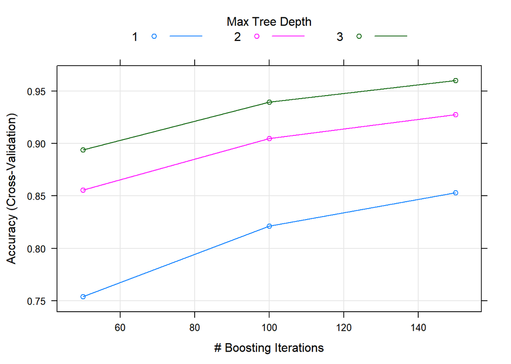

```r
plot(mod_GBM)
```

This Graddient boosting gives 0.9635 that is pretty fine

##### Lets look at the prediction output for test file data

```r
pred_DT <- predict(mod_DT, data_test)
pred_DT
```

```
##             A           B           C          D          E
## 1  0.10370370 0.785185185 0.037037037 0.00000000 0.07407407
## 2  0.66555184 0.197881828 0.018394649 0.08751394 0.03065775
## 3  0.05668605 0.191860465 0.186046512 0.16424419 0.40116279
## 4  0.12897822 0.023450586 0.107202680 0.70686767 0.03350084
## 5  0.70662461 0.138801262 0.012618297 0.09463722 0.04731861
## 6  0.03343849 0.095268139 0.558359621 0.16403785 0.14889590
## 7  0.06666667 0.129166667 0.039583333 0.70833333 0.05625000
## 8  0.70662461 0.138801262 0.012618297 0.09463722 0.04731861
## 9  0.99463519 0.005364807 0.000000000 0.00000000 0.00000000
## 10 0.66555184 0.197881828 0.018394649 0.08751394 0.03065775
## 11 0.03343849 0.095268139 0.558359621 0.16403785 0.14889590
## 12 0.05668605 0.191860465 0.186046512 0.16424419 0.40116279
## 13 0.03343849 0.095268139 0.558359621 0.16403785 0.14889590
## 14 0.99463519 0.005364807 0.000000000 0.00000000 0.00000000
## 15 0.05668605 0.191860465 0.186046512 0.16424419 0.40116279
## 16 0.03816794 0.125954198 0.000000000 0.19465649 0.64122137
## 17 0.96551724 0.000000000 0.017241379 0.00000000 0.01724138
## 18 0.66555184 0.197881828 0.018394649 0.08751394 0.03065775
## 19 0.66555184 0.197881828 0.018394649 0.08751394 0.03065775
## 20 0.03773585 0.792452830 0.006289308 0.06918239 0.09433962
```

```r
pred_RF <- predict(mod_RF, data_test)
pred_RF
```

```
##  1  2  3  4  5  6  7  8  9 10 11 12 13 14 15 16 17 18 19 20
##  B  A  B  A  A  E  D  B  A  A  B  C  B  A  E  E  A  B  B  B
## Levels: A B C D E
```

```r
pred_GBM <- predict(mod_GBM, data_test)
pred_GBM
```

```
##  [1] B A B A A E D B A A B C B A E E A B B B
## Levels: A B C D E
```